# Full 7q22 Output Data Preparation and Preliminary Investigation

Edward Plugge

This document details the steps taken after local SNP-to-metabolite analysis of the 7q22 locus has been performed and the 34 output files have been cleaned (comments removed) The purpose is to impose a cutoff for low MAF SNPs; to excluding alleles with a MAF threshold that is based upon stratified QQ plots. Finally, the data can be preliminarily visualised with local manhattan plots in order for further investigation to be performed. The resulting file “listcopy” contains the initial statistics that can be exported for input into more powerful web-tool based regional association plotting tools, such as SNiPA.com: https://snipa.helmholtz-muenchen.de/snipa3/?task=regional_association_plot

# Chapter 1: Setup

```r
# Define working dir and load packages
ROOT_loc = "/Users/edwardplugge/Documents/UMC/UCORBIO/Full 7Q22 Output"
INPUT_loc = paste0(ROOT_loc,"/Input")
OUTPUT_loc = paste0(ROOT_loc,"/Output")
PLOT_loc = paste0(ROOT_loc,"/Plots")

setwd(paste0(ROOT_loc))

library(tidyverse)
library(stringr)
library(CMplot)
library(data.table)
library(fdrtool)
library(qvalue)
library(RACER)
```

# Chapter 2: Importing, listing, cleaning and preparing SNPTEST output files for plot generation

The chosen phenotypes must be listed as they are written in the SNPTEST output files

```r
# Define the list of phenotypes
phenotypes <- c("Ala_Z", "ApoA1_Z", "ApoB_ratio_ApoA1_Z", "ApoB_Z", "Crea_Z",
                "EstC_Z", "FAw3_Z", "FAw6_Z", "FreeC_Z", "Gln_Z", "IDL_P_Z",
                "L_HDL_P_Z", "L_LDL_P_Z", "L_VLDL_P_Z", "LA_Z", "Leu_Z",
                "M_HDL_P_Z", "M_LDL_P_Z", "M_VLDL_P_Z", "MUFA_Z", "PC_Z",
                "PUFA_Z", "S_HDL_P_Z", "S_LDL_P_Z", "S_VLDL_P_Z", "Serum_C_Z",
                "Serum_TG_Z", "SFA_Z", "TotFA_Z", "TotPG_Z", "XL_HDL_P_Z",
                "XL_VLDL_P_Z", "XS_VLDL_P_Z", "XXL_VLDL_P_Z")
```

The data import can then be automated, as well as the cleaning of some unwanted results. N.B. this chunk writes .txt output files for each phenotype that can be read into the plot chunk below. The region analysed is Chr7:106500000-107650000 (for Build GRCHh37.p13)

```r
temp = list.files(paste0(INPUT_loc), pattern="*.jobarray.out")
list = lapply(paste0(INPUT_loc,"/",temp), function(i){
  read.csv(i, header=TRUE, sep = " ")
})
```

```r
data=list()
for(i in 1:length(list)){
list[[i]] <- list[[i]] %>%
  filter(!grepl('frequentist_add:model_not_fit:design_matrix_singular_value_below_limit', comment))
data[[i]] <- subset(list[[i]], select = c("frequentist_add_pvalue", "all_maf", "info"))
names(data[[i]])[names(data[[i]]) == "frequentist_add_pvalue"] <- "P"
names(data[[i]])[names(data[[i]]) == "all_maf"] <- "CAF"
names(data[[i]])[names(data[[i]]) == "info"] <- "INFO"
fwrite(data[[i]], file = paste0(OUTPUT_loc, "/", paste0(phenotypes[[i]],"_plot.txt")), col.names = TRUE, sep = " ")
}

# Copy list for redundancy, so import doesn't have to be repeated

listcopy <- list
```

# Chapter 3: Summarising initial data with descriptive statistics and QQ plots

The general statistics of each MAF can then be summarised

```r
MAFlist = lapply(listcopy, function(x) x%>% select(19))
sapply(MAFlist, summary)
```

This chunk runs the plot_gwas.R command which is configured to produce a stratified QQplot png for each phenotype. To change the plot content the .txt file must be re-written. This chunk may take some time.

```r
for(i in phenotypes){
system(paste0("R CMD BATCH -",i,"_plot.txt -",i,".out plot_gwas.R"))
}
```

Two examples of stratified QQ plots are shown

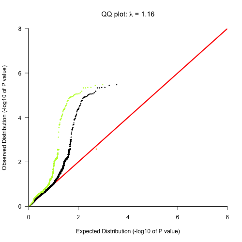

SNP-to-Large LDL

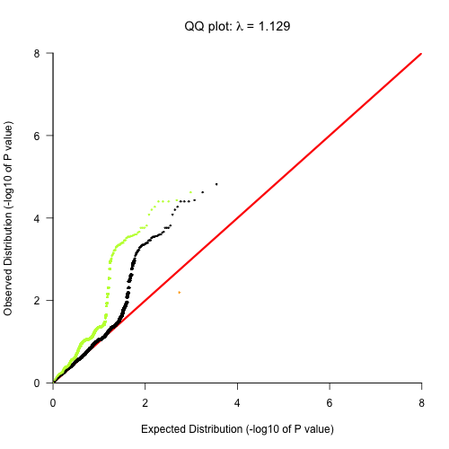

SNP-to-ApoB

The pattern acrosss the majority of plots demonstrates that SNPs with a MAF < 0.01, and to a degree between 0.01 and 0.05 show significant early separation of the observed from the expected, as well as a overwhelming skewing effect on the average plotted values across all MAF levels (shown in black under “observed”). Therefore the original lists must be subjected to a MAF cutoff based on a determined threshold that reflects this.

```r
# Filters MAF in all dfs in list based on selected value
listcopy = lapply(listcopy, function(df) {
  filter(df, all_maf > 0.05)
})
```

# Chapter 4: Correcting for Type I errors with CMT - Correction for Multiple Testing

First we can inspect the descriptives statistics of the P-value for each metabolite.

```r
# Extract P value from output data frame
Pvaluelist = lapply(listcopy, function(x) x%>% select(2:4,22))
# Create name for all columns
colnames <- c("SNP","chr","pos","pvalue")
# Assign name to each data frame
Pvaluelist <- lapply(Pvaluelist, setNames, colnames)
# Rename Columns
names(Pvaluelist) <- c(paste0(phenotypes))
# Provide a summary
#sapply(Pvaluelist, summary(pvalue))
```

```r
# Find the average number of SNPs tested across all metabolites
number.of.tests <- sapply(list, nrow)

# Bonferroni correction: Finding alpha for

alpha <- 0.05/print(mean(number.of.tests))
print(alpha)
```

A quick investigation of correlation within metabolites reveals groups with similar patterns:

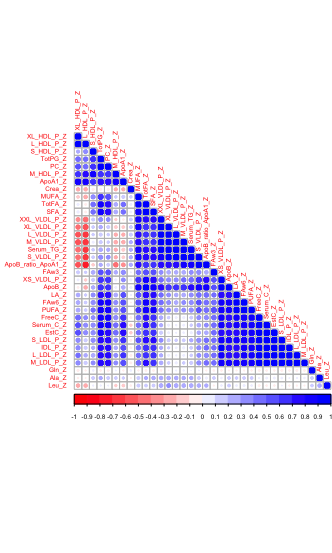

7Q22 Metabolite Correlation Plot

The above correlation plot shows the correlation between all 34 metabolites ordered by heirarchical cluster to reveal a simple measure of substructure of similarity in the groups.

As expected, subgroups of the same, or very similar lipiprotein fraction are generally positively correlated with eachother, since the 14 classes are can broadly be distinguished from eachother based on a continous scale of decreasing size and increasing density, from XXL VLDL (Extremely large very-low-density lipoprotein, to XS HDL (extremely small high-density lipoprotein).

```r
# Filters Pvalues in all dfs in list based on selected value
BonferroniList = lapply(Pvaluelist, function(df) {
  filter(df, pvalue < print(alpha))
})
```

# Chapter 5: Correcting for FWER: Family wise error rate with FDR (False discovery rate)

The false discovery rate (FDR) is the expected proportion of false rejections out of all rejections.This chunk prepares the data for an FWER later on. The FWER method is preferred in place of the above described bonferroni method in the case of assumed independance and a need for a less conservative correction tool.

```r
# False Discovery Rate for Ala

Qobjectlist = lapply(Pvaluelist, function(df) {
  qobj = qvalue(p = df$pvalue)
  return(qobj)
})

# Once the qvalue object is created, estimates of the q-values, the proportion of true null hypotheses,
# and the local false discovery rates can be accessed from qobj:
```

N.B. The intitial input file contains over 3000 tests performed. After trimming for maf <0.05 this leaves 1500 remaining. Here, these results can be visualised before further investigation.

```r
##Options for visualising results
#summary(Pvaluelist$ApoB_Z)

#hist(Pvaluelist$L_LDL_P_Z)

#plot(qobj)

## Options for visualising histograms and summary stats for a specified output result, in rhis case IDL

#hist(-log10(Qobjectlist$IDL_P_Z$pvalue))

#summary(Qobjectlist$IDL_P_Z)

#plot(Qobjectlist$IDL_P_Z)

#hist(Qobjectlist$IDL_P_Z)
```

```
 Rectangular_Manhattan Plotting q.
 Rectangular_Manhattan Plotting q.
```

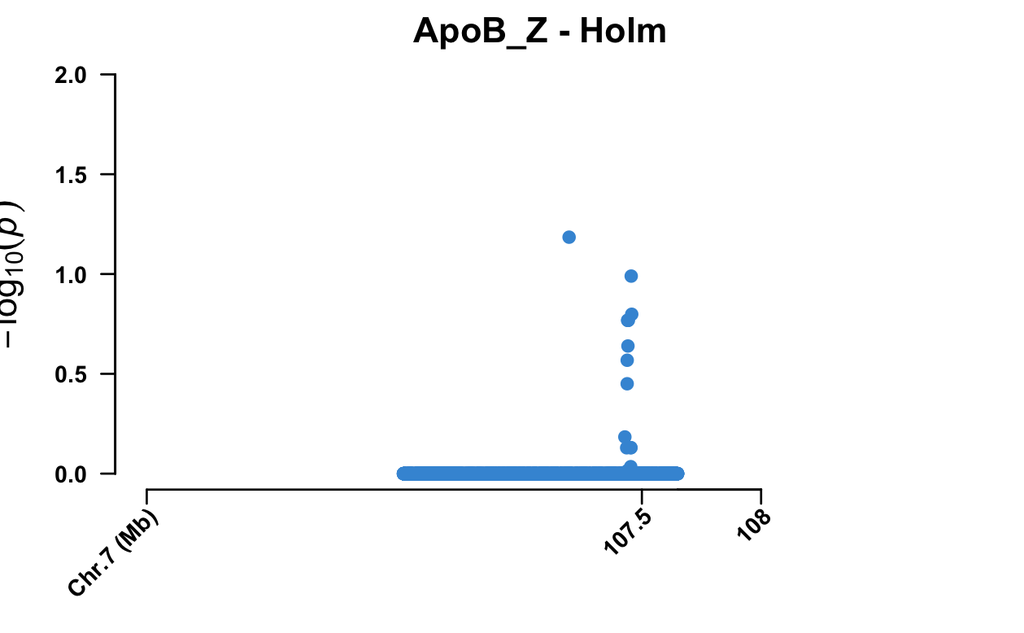

```
 Rectangular_Manhattan Plotting q.
```

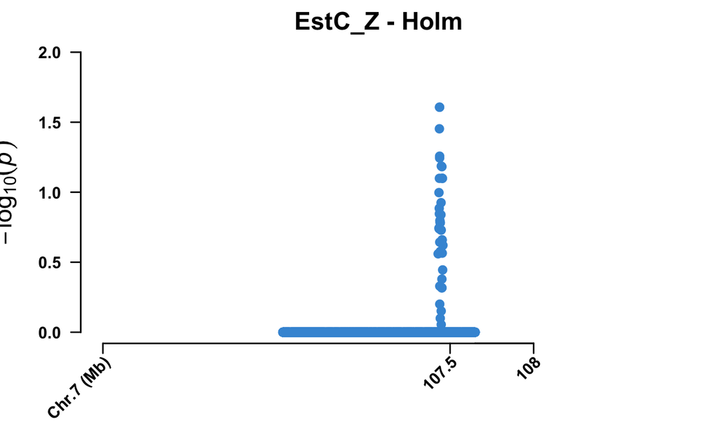

```
 Rectangular_Manhattan Plotting q.
```

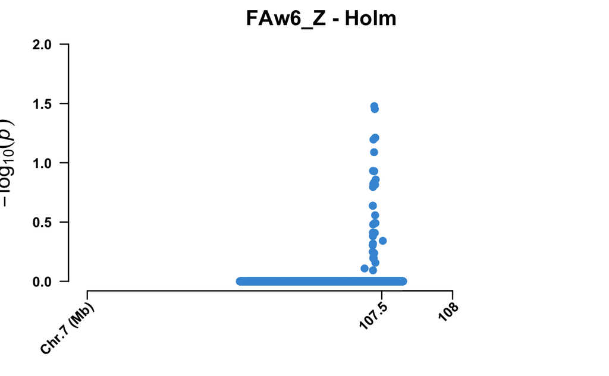

```
 Rectangular_Manhattan Plotting q.
```

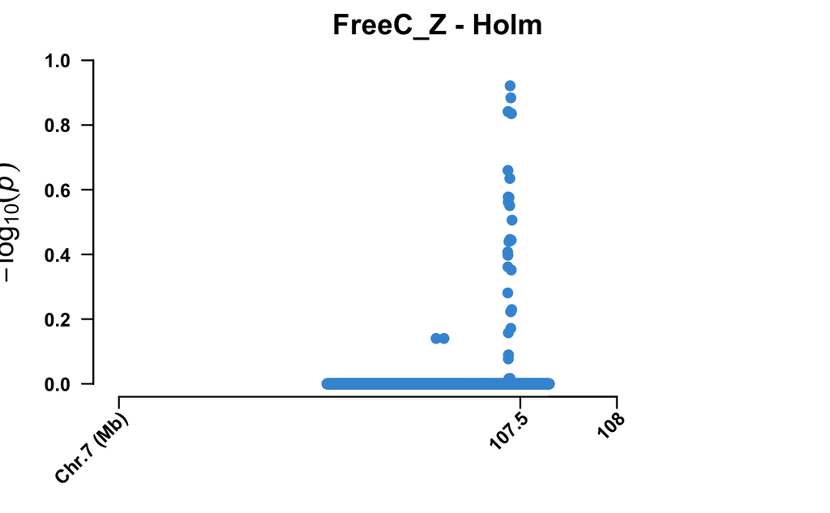

```
 Rectangular_Manhattan Plotting q.
```

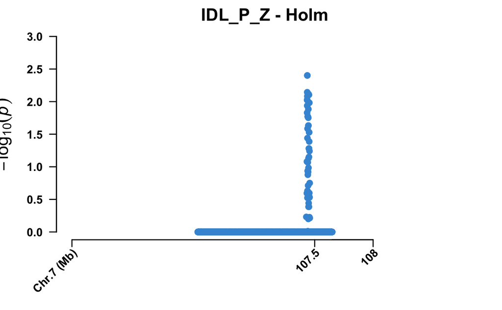

```
 Rectangular_Manhattan Plotting q.
```

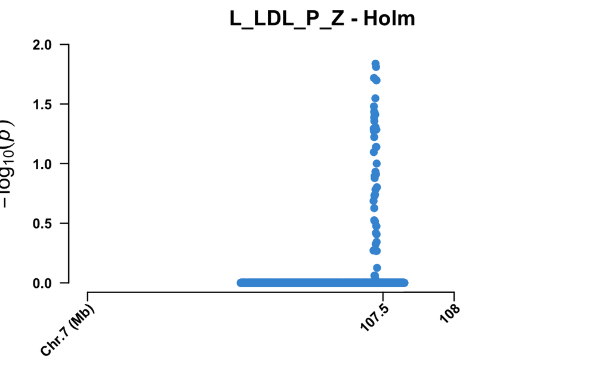

```
 Rectangular_Manhattan Plotting q.
```

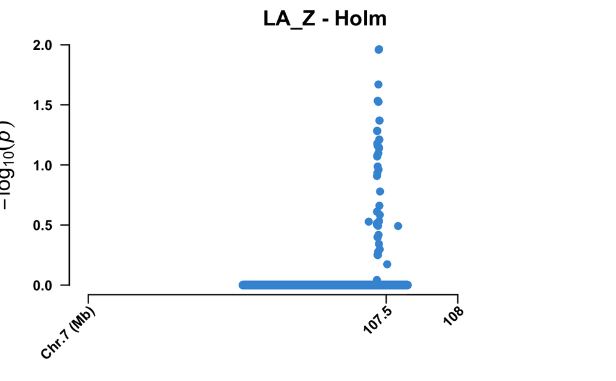

```
 Rectangular_Manhattan Plotting q.
```

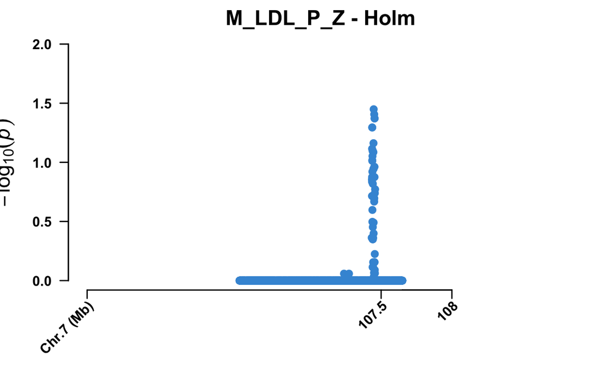

```
 Rectangular_Manhattan Plotting q.
```

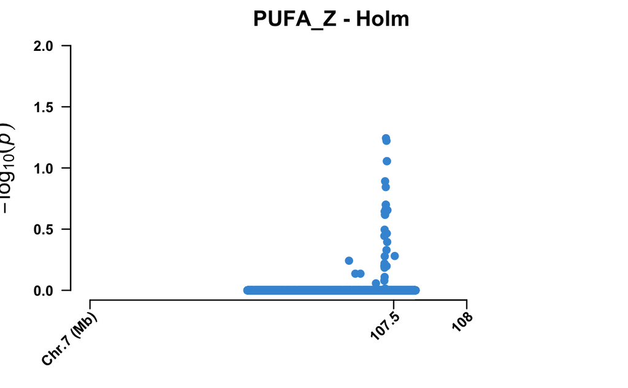

```
 Rectangular_Manhattan Plotting q.
```

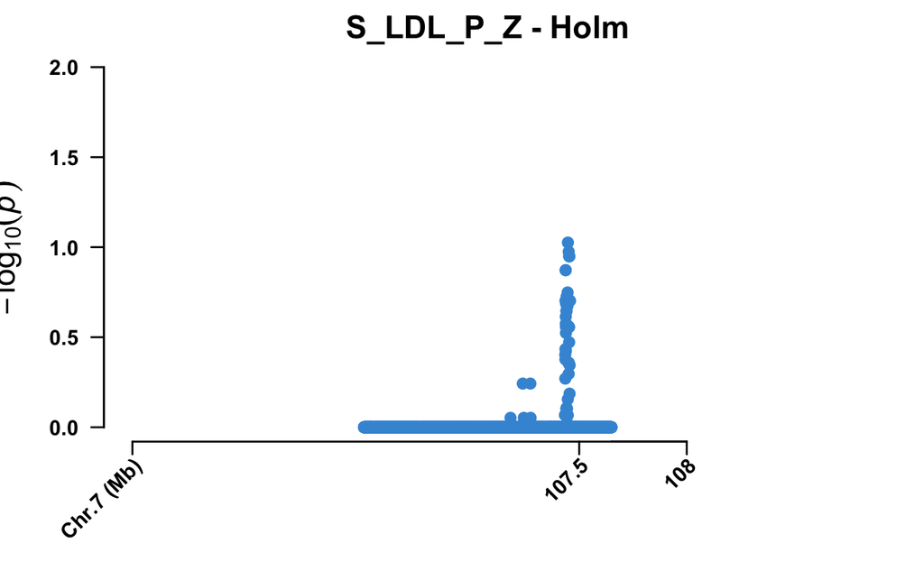

```
 Rectangular_Manhattan Plotting q.
```

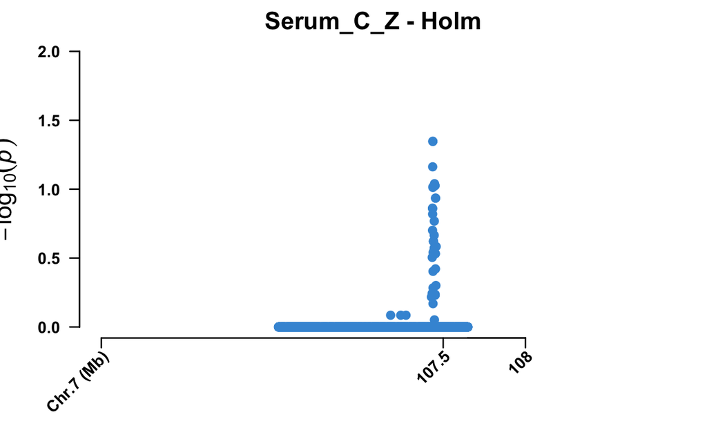

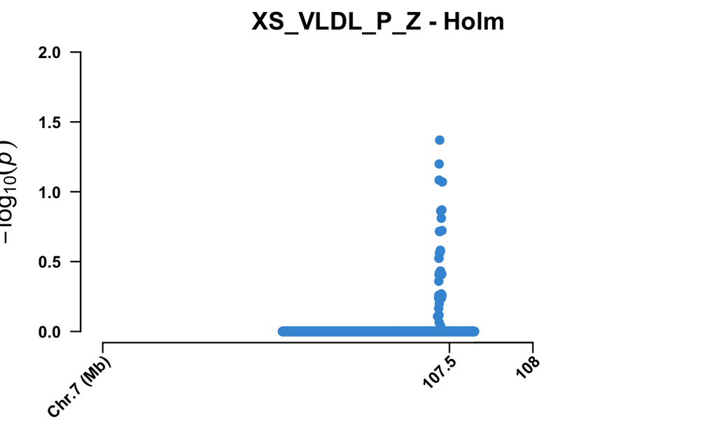

```r
Qvaluelist2 = lapply(Pvaluelist, function(input) {
  q <- p.adjust(input$pvalue, method = "holm")
  q <- as.data.frame(q)
  qout <- cbind(input[1:3],q)
  qout
})

# Significant phenotypes have been isolated for further study here.
sig_phenotypes <- phenotypes[c(4,6,8,9,11,13,15,18,22,24,26,33)]

for (i in sig_phenotypes) {
  df = Qvaluelist2[[i]]
  CMplot(df,type="p",plot.type="m",main=sprintf("%s - Holm", i), LOG10=TRUE,file="jpg",memo="",dpi=300,
       file.output=FALSE,verbose=TRUE,width=14,height=6,chr.labels.angle=45)
}
```

P.S. For further investigation, a SNP (base pair location format as shown below) may be highlighted here to investigate loci of interest. Alternatively, SNPs below and above a certain p-value can be isolated, which is especially useful when using the HOLM correction method which assigns non-significant values as q=1

```r
IDL<- Qvaluelist2$IDL_P_Z
SNP <- IDL[IDL$q < 0.05, 1]
SNPrs <- as.character("7:107091849")

#geneSNPs <-
#genes <- paste("COG5", 1:length(geneSNPs), sep="_")
#rm(IDL,SNP)
```

Once a preliminary investigation is done, the original files in “listcopy” can be trimmed and imported into https://snipa.helmholtz-muenchen.de/snipa3/?task=regional_association_plot or any preferred tool where more powerful and interactive regional association plots can be made. Input file formats differ for each tool and are not described here.